# Risk Factor Analysis

## Outcome Variable

**Outcome Variable:** y_rate_wtkg

## Predictor Variables

**Intervention Variable:** impsan

**Adjustment Set:**

- arm
- sex
- W_mage
- meducyrs
- feducyrs
- hhwealth_quart
- hfoodsec
- W_mhtcm
- W_mwtkg
- W_mbmi
- single
- W_nrooms
- W_parity
- impfloor
- safeh20
- delta_W_mage
- delta_meducyrs
- delta_feducyrs
- delta_hhwealth_quart
- delta_hfoodsec
- delta_W_mhtcm
- delta_W_mwtkg
- delta_W_mbmi
- delta_single
- delta_W_nrooms
- delta_W_parity
- delta_impfloor
- delta_safeh20

## Stratifying Variables

The analysis was stratified on these variable(s):

- agecat
- studyid
- country

## Data Summary

| agecat | studyid | country | impsan | n_cell | n | outcome_variable |
| --- | --- | --- | --- | --- | --- | --- |
| 0-3 months | ki0047075b-MAL-ED | BANGLADESH | 1 | 201 | 239 | y_rate_wtkg |
| 0-3 months | ki0047075b-MAL-ED | BANGLADESH | 0 | 38 | 239 | y_rate_wtkg |
| 0-3 months | ki0047075b-MAL-ED | BRAZIL | 1 | 206 | 210 | y_rate_wtkg |
| 0-3 months | ki0047075b-MAL-ED | BRAZIL | 0 | 4 | 210 | y_rate_wtkg |
| 0-3 months | ki0047075b-MAL-ED | INDIA | 1 | 106 | 230 | y_rate_wtkg |
| 0-3 months | ki0047075b-MAL-ED | INDIA | 0 | 124 | 230 | y_rate_wtkg |
| 0-3 months | ki0047075b-MAL-ED | NEPAL | 1 | 229 | 230 | y_rate_wtkg |
| 0-3 months | ki0047075b-MAL-ED | NEPAL | 0 | 1 | 230 | y_rate_wtkg |
| 0-3 months | ki0047075b-MAL-ED | PERU | 1 | 64 | 262 | y_rate_wtkg |
| 0-3 months | ki0047075b-MAL-ED | PERU | 0 | 198 | 262 | y_rate_wtkg |
| 0-3 months | ki0047075b-MAL-ED | SOUTH AFRICA | 1 | 4 | 248 | y_rate_wtkg |
| 0-3 months | ki0047075b-MAL-ED | SOUTH AFRICA | 0 | 244 | 248 | y_rate_wtkg |
| 0-3 months | ki0047075b-MAL-ED | TANZANIA, UNITED REPUBLIC OF | 1 | 0 | 224 | y_rate_wtkg |
| 0-3 months | ki0047075b-MAL-ED | TANZANIA, UNITED REPUBLIC OF | 0 | 224 | 224 | y_rate_wtkg |
| 0-3 months | ki1017093-NIH-Birth | BANGLADESH | 1 | 217 | 565 | y_rate_wtkg |
| 0-3 months | ki1017093-NIH-Birth | BANGLADESH | 0 | 348 | 565 | y_rate_wtkg |
| 0-3 months | ki1017093b-PROVIDE | BANGLADESH | 1 | 13 | 13 | y_rate_wtkg |
| 0-3 months | ki1017093b-PROVIDE | BANGLADESH | 0 | 0 | 13 | y_rate_wtkg |
| 0-3 months | ki1017093c-NIH-Crypto | BANGLADESH | 1 | 629 | 714 | y_rate_wtkg |
| 0-3 months | ki1017093c-NIH-Crypto | BANGLADESH | 0 | 85 | 714 | y_rate_wtkg |
| 0-3 months | ki1114097-CONTENT | PERU | 1 | 25 | 29 | y_rate_wtkg |
| 0-3 months | ki1114097-CONTENT | PERU | 0 | 4 | 29 | y_rate_wtkg |
| 0-3 months | ki1135781-COHORTS | GUATEMALA | 1 | 55 | 514 | y_rate_wtkg |
| 0-3 months | ki1135781-COHORTS | GUATEMALA | 0 | 459 | 514 | y_rate_wtkg |
| 0-3 months | ki1135781-COHORTS | INDIA | 1 | 1808 | 4802 | y_rate_wtkg |
| 0-3 months | ki1135781-COHORTS | INDIA | 0 | 2994 | 4802 | y_rate_wtkg |
| 0-3 months | kiGH5241-JiVitA-3 | BANGLADESH | 1 | 13895 | 20271 | y_rate_wtkg |
| 0-3 months | kiGH5241-JiVitA-3 | BANGLADESH | 0 | 6376 | 20271 | y_rate_wtkg |
| 0-3 months | kiGH5241-JiVitA-4 | BANGLADESH | 1 | 1937 | 2496 | y_rate_wtkg |
| 0-3 months | kiGH5241-JiVitA-4 | BANGLADESH | 0 | 559 | 2496 | y_rate_wtkg |

[output cut: 198 more lines]

The following strata were considered:

- agecat: 0-3 months, studyid: ki0047075b-MAL-ED, country: BANGLADESH
- agecat: 0-3 months, studyid: ki0047075b-MAL-ED, country: BRAZIL
- agecat: 0-3 months, studyid: ki0047075b-MAL-ED, country: INDIA
- agecat: 0-3 months, studyid: ki0047075b-MAL-ED, country: NEPAL
- agecat: 0-3 months, studyid: ki0047075b-MAL-ED, country: PERU
- agecat: 0-3 months, studyid: ki0047075b-MAL-ED, country: SOUTH AFRICA
- agecat: 0-3 months, studyid: ki0047075b-MAL-ED, country: TANZANIA, UNITED REPUBLIC OF
- agecat: 0-3 months, studyid: ki1017093-NIH-Birth, country: BANGLADESH
- agecat: 0-3 months, studyid: ki1017093b-PROVIDE, country: BANGLADESH
- agecat: 0-3 months, studyid: ki1017093c-NIH-Crypto, country: BANGLADESH
- agecat: 0-3 months, studyid: ki1114097-CONTENT, country: PERU
- agecat: 0-3 months, studyid: ki1135781-COHORTS, country: GUATEMALA
- agecat: 0-3 months, studyid: ki1135781-COHORTS, country: INDIA
- agecat: 0-3 months, studyid: kiGH5241-JiVitA-3, country: BANGLADESH
- agecat: 0-3 months, studyid: kiGH5241-JiVitA-4, country: BANGLADESH
- agecat: 12-15 months, studyid: ki0047075b-MAL-ED, country: BANGLADESH
- agecat: 12-15 months, studyid: ki0047075b-MAL-ED, country: BRAZIL
- agecat: 12-15 months, studyid: ki0047075b-MAL-ED, country: INDIA
- agecat: 12-15 months, studyid: ki0047075b-MAL-ED, country: NEPAL
- agecat: 12-15 months, studyid: ki0047075b-MAL-ED, country: PERU
- agecat: 12-15 months, studyid: ki0047075b-MAL-ED, country: SOUTH AFRICA
- agecat: 12-15 months, studyid: ki0047075b-MAL-ED, country: TANZANIA, UNITED REPUBLIC OF
- agecat: 12-15 months, studyid: ki1017093-NIH-Birth, country: BANGLADESH
- agecat: 12-15 months, studyid: ki1017093b-PROVIDE, country: BANGLADESH
- agecat: 12-15 months, studyid: ki1017093c-NIH-Crypto, country: BANGLADESH
- agecat: 12-15 months, studyid: ki1114097-CONTENT, country: PERU
- agecat: 12-15 months, studyid: ki1135781-COHORTS, country: GUATEMALA
- agecat: 12-15 months, studyid: ki1148112-LCNI-5, country: MALAWI
- agecat: 12-15 months, studyid: kiGH5241-JiVitA-4, country: BANGLADESH
- agecat: 15-18 months, studyid: ki0047075b-MAL-ED, country: BANGLADESH
- agecat: 15-18 months, studyid: ki0047075b-MAL-ED, country: BRAZIL
- agecat: 15-18 months, studyid: ki0047075b-MAL-ED, country: INDIA
- agecat: 15-18 months, studyid: ki0047075b-MAL-ED, country: NEPAL
- agecat: 15-18 months, studyid: ki0047075b-MAL-ED, country: PERU
- agecat: 15-18 months, studyid: ki0047075b-MAL-ED, country: SOUTH AFRICA
- agecat: 15-18 months, studyid: ki0047075b-MAL-ED, country: TANZANIA, UNITED REPUBLIC OF
- agecat: 15-18 months, studyid: ki1017093-NIH-Birth, country: BANGLADESH
- agecat: 15-18 months, studyid: ki1017093b-PROVIDE, country: BANGLADESH
- agecat: 15-18 months, studyid: ki1017093c-NIH-Crypto, country: BANGLADESH
- agecat: 15-18 months, studyid: ki1114097-CONTENT, country: PERU
- agecat: 15-18 months, studyid: ki1135781-COHORTS, country: GUATEMALA
- agecat: 15-18 months, studyid: ki1148112-LCNI-5, country: MALAWI
- agecat: 15-18 months, studyid: kiGH5241-JiVitA-4, country: BANGLADESH
- agecat: 18-21 months, studyid: ki0047075b-MAL-ED, country: BANGLADESH
- agecat: 18-21 months, studyid: ki0047075b-MAL-ED, country: BRAZIL
- agecat: 18-21 months, studyid: ki0047075b-MAL-ED, country: INDIA
- agecat: 18-21 months, studyid: ki0047075b-MAL-ED, country: NEPAL
- agecat: 18-21 months, studyid: ki0047075b-MAL-ED, country: PERU
- agecat: 18-21 months, studyid: ki0047075b-MAL-ED, country: SOUTH AFRICA
- agecat: 18-21 months, studyid: ki0047075b-MAL-ED, country: TANZANIA, UNITED REPUBLIC OF
- agecat: 18-21 months, studyid: ki1017093-NIH-Birth, country: BANGLADESH
- agecat: 18-21 months, studyid: ki1017093b-PROVIDE, country: BANGLADESH
- agecat: 18-21 months, studyid: ki1017093c-NIH-Crypto, country: BANGLADESH
- agecat: 18-21 months, studyid: ki1114097-CONTENT, country: PERU
- agecat: 18-21 months, studyid: ki1135781-COHORTS, country: GUATEMALA
- agecat: 18-21 months, studyid: ki1148112-LCNI-5, country: MALAWI
- agecat: 21-24 months, studyid: ki0047075b-MAL-ED, country: BANGLADESH
- agecat: 21-24 months, studyid: ki0047075b-MAL-ED, country: BRAZIL
- agecat: 21-24 months, studyid: ki0047075b-MAL-ED, country: INDIA
- agecat: 21-24 months, studyid: ki0047075b-MAL-ED, country: NEPAL
- agecat: 21-24 months, studyid: ki0047075b-MAL-ED, country: PERU
- agecat: 21-24 months, studyid: ki0047075b-MAL-ED, country: SOUTH AFRICA
- agecat: 21-24 months, studyid: ki0047075b-MAL-ED, country: TANZANIA, UNITED REPUBLIC OF
- agecat: 21-24 months, studyid: ki1017093-NIH-Birth, country: BANGLADESH
- agecat: 21-24 months, studyid: ki1017093b-PROVIDE, country: BANGLADESH
- agecat: 21-24 months, studyid: ki1017093c-NIH-Crypto, country: BANGLADESH
- agecat: 21-24 months, studyid: ki1114097-CONTENT, country: PERU
- agecat: 21-24 months, studyid: ki1135781-COHORTS, country: GUATEMALA
- agecat: 21-24 months, studyid: ki1148112-LCNI-5, country: MALAWI
- agecat: 3-6 months, studyid: ki0047075b-MAL-ED, country: BANGLADESH
- agecat: 3-6 months, studyid: ki0047075b-MAL-ED, country: BRAZIL
- agecat: 3-6 months, studyid: ki0047075b-MAL-ED, country: INDIA
- agecat: 3-6 months, studyid: ki0047075b-MAL-ED, country: NEPAL
- agecat: 3-6 months, studyid: ki0047075b-MAL-ED, country: PERU
- agecat: 3-6 months, studyid: ki0047075b-MAL-ED, country: SOUTH AFRICA
- agecat: 3-6 months, studyid: ki0047075b-MAL-ED, country: TANZANIA, UNITED REPUBLIC OF
- agecat: 3-6 months, studyid: ki1017093-NIH-Birth, country: BANGLADESH
- agecat: 3-6 months, studyid: ki1017093b-PROVIDE, country: BANGLADESH
- agecat: 3-6 months, studyid: ki1017093c-NIH-Crypto, country: BANGLADESH
- agecat: 3-6 months, studyid: ki1114097-CONTENT, country: PERU
- agecat: 3-6 months, studyid: ki1135781-COHORTS, country: GUATEMALA
- agecat: 3-6 months, studyid: ki1135781-COHORTS, country: INDIA
- agecat: 3-6 months, studyid: kiGH5241-JiVitA-3, country: BANGLADESH
- agecat: 3-6 months, studyid: kiGH5241-JiVitA-4, country: BANGLADESH
- agecat: 6-9 months, studyid: ki0047075b-MAL-ED, country: BANGLADESH
- agecat: 6-9 months, studyid: ki0047075b-MAL-ED, country: BRAZIL
- agecat: 6-9 months, studyid: ki0047075b-MAL-ED, country: INDIA
- agecat: 6-9 months, studyid: ki0047075b-MAL-ED, country: NEPAL
- agecat: 6-9 months, studyid: ki0047075b-MAL-ED, country: PERU
- agecat: 6-9 months, studyid: ki0047075b-MAL-ED, country: SOUTH AFRICA
- agecat: 6-9 months, studyid: ki0047075b-MAL-ED, country: TANZANIA, UNITED REPUBLIC OF
- agecat: 6-9 months, studyid: ki1017093-NIH-Birth, country: BANGLADESH
- agecat: 6-9 months, studyid: ki1017093b-PROVIDE, country: BANGLADESH
- agecat: 6-9 months, studyid: ki1017093c-NIH-Crypto, country: BANGLADESH
- agecat: 6-9 months, studyid: ki1114097-CONTENT, country: PERU
- agecat: 6-9 months, studyid: ki1135781-COHORTS, country: GUATEMALA
- agecat: 6-9 months, studyid: ki1135781-COHORTS, country: INDIA
- agecat: 6-9 months, studyid: ki1148112-LCNI-5, country: MALAWI
- agecat: 6-9 months, studyid: kiGH5241-JiVitA-4, country: BANGLADESH
- agecat: 9-12 months, studyid: ki0047075b-MAL-ED, country: BANGLADESH
- agecat: 9-12 months, studyid: ki0047075b-MAL-ED, country: BRAZIL
- agecat: 9-12 months, studyid: ki0047075b-MAL-ED, country: INDIA
- agecat: 9-12 months, studyid: ki0047075b-MAL-ED, country: NEPAL
- agecat: 9-12 months, studyid: ki0047075b-MAL-ED, country: PERU
- agecat: 9-12 months, studyid: ki0047075b-MAL-ED, country: SOUTH AFRICA
- agecat: 9-12 months, studyid: ki0047075b-MAL-ED, country: TANZANIA, UNITED REPUBLIC OF
- agecat: 9-12 months, studyid: ki1017093-NIH-Birth, country: BANGLADESH
- agecat: 9-12 months, studyid: ki1017093b-PROVIDE, country: BANGLADESH
- agecat: 9-12 months, studyid: ki1017093c-NIH-Crypto, country: BANGLADESH
- agecat: 9-12 months, studyid: ki1114097-CONTENT, country: PERU
- agecat: 9-12 months, studyid: ki1135781-COHORTS, country: GUATEMALA
- agecat: 9-12 months, studyid: ki1135781-COHORTS, country: INDIA
- agecat: 9-12 months, studyid: ki1148112-LCNI-5, country: MALAWI
- agecat: 9-12 months, studyid: kiGH5241-JiVitA-4, country: BANGLADESH

### Dropped Strata

Some strata were dropped due to rare outcomes:

- agecat: 0-3 months, studyid: ki0047075b-MAL-ED, country: BRAZIL
- agecat: 0-3 months, studyid: ki0047075b-MAL-ED, country: NEPAL
- agecat: 0-3 months, studyid: ki0047075b-MAL-ED, country: SOUTH AFRICA
- agecat: 0-3 months, studyid: ki0047075b-MAL-ED, country: TANZANIA, UNITED REPUBLIC OF
- agecat: 0-3 months, studyid: ki1017093b-PROVIDE, country: BANGLADESH
- agecat: 0-3 months, studyid: ki1114097-CONTENT, country: PERU
- agecat: 3-6 months, studyid: ki0047075b-MAL-ED, country: BRAZIL
- agecat: 3-6 months, studyid: ki0047075b-MAL-ED, country: NEPAL
- agecat: 3-6 months, studyid: ki0047075b-MAL-ED, country: SOUTH AFRICA
- agecat: 3-6 months, studyid: ki0047075b-MAL-ED, country: TANZANIA, UNITED REPUBLIC OF
- agecat: 3-6 months, studyid: ki1017093b-PROVIDE, country: BANGLADESH
- agecat: 6-9 months, studyid: ki0047075b-MAL-ED, country: BRAZIL
- agecat: 6-9 months, studyid: ki0047075b-MAL-ED, country: NEPAL
- agecat: 6-9 months, studyid: ki0047075b-MAL-ED, country: SOUTH AFRICA
- agecat: 6-9 months, studyid: ki0047075b-MAL-ED, country: TANZANIA, UNITED REPUBLIC OF
- agecat: 6-9 months, studyid: ki1017093b-PROVIDE, country: BANGLADESH
- agecat: 6-9 months, studyid: ki1148112-LCNI-5, country: MALAWI
- agecat: 9-12 months, studyid: ki0047075b-MAL-ED, country: BRAZIL
- agecat: 9-12 months, studyid: ki0047075b-MAL-ED, country: NEPAL
- agecat: 9-12 months, studyid: ki0047075b-MAL-ED, country: SOUTH AFRICA
- agecat: 9-12 months, studyid: ki0047075b-MAL-ED, country: TANZANIA, UNITED REPUBLIC OF
- agecat: 9-12 months, studyid: ki1017093b-PROVIDE, country: BANGLADESH
- agecat: 9-12 months, studyid: ki1148112-LCNI-5, country: MALAWI
- agecat: 12-15 months, studyid: ki0047075b-MAL-ED, country: BRAZIL
- agecat: 12-15 months, studyid: ki0047075b-MAL-ED, country: NEPAL
- agecat: 12-15 months, studyid: ki0047075b-MAL-ED, country: SOUTH AFRICA
- agecat: 12-15 months, studyid: ki0047075b-MAL-ED, country: TANZANIA, UNITED REPUBLIC OF
- agecat: 12-15 months, studyid: ki1017093b-PROVIDE, country: BANGLADESH
- agecat: 12-15 months, studyid: ki1148112-LCNI-5, country: MALAWI
- agecat: 15-18 months, studyid: ki0047075b-MAL-ED, country: BRAZIL
- agecat: 15-18 months, studyid: ki0047075b-MAL-ED, country: NEPAL
- agecat: 15-18 months, studyid: ki0047075b-MAL-ED, country: SOUTH AFRICA
- agecat: 15-18 months, studyid: ki0047075b-MAL-ED, country: TANZANIA, UNITED REPUBLIC OF
- agecat: 15-18 months, studyid: ki1017093b-PROVIDE, country: BANGLADESH
- agecat: 15-18 months, studyid: ki1148112-LCNI-5, country: MALAWI
- agecat: 18-21 months, studyid: ki0047075b-MAL-ED, country: BRAZIL
- agecat: 18-21 months, studyid: ki0047075b-MAL-ED, country: NEPAL
- agecat: 18-21 months, studyid: ki0047075b-MAL-ED, country: SOUTH AFRICA
- agecat: 18-21 months, studyid: ki0047075b-MAL-ED, country: TANZANIA, UNITED REPUBLIC OF
- agecat: 18-21 months, studyid: ki1017093b-PROVIDE, country: BANGLADESH
- agecat: 18-21 months, studyid: ki1148112-LCNI-5, country: MALAWI
- agecat: 21-24 months, studyid: ki0047075b-MAL-ED, country: BRAZIL
- agecat: 21-24 months, studyid: ki0047075b-MAL-ED, country: NEPAL
- agecat: 21-24 months, studyid: ki0047075b-MAL-ED, country: SOUTH AFRICA
- agecat: 21-24 months, studyid: ki0047075b-MAL-ED, country: TANZANIA, UNITED REPUBLIC OF
- agecat: 21-24 months, studyid: ki1017093b-PROVIDE, country: BANGLADESH
- agecat: 21-24 months, studyid: ki1114097-CONTENT, country: PERU
- agecat: 21-24 months, studyid: ki1148112-LCNI-5, country: MALAWI

## Methods Detail

We’re interested in the causal parameters $E[Y_a]$ for all values of $a \in \mathcal{A}$. These parameters represent the mean outcome if, possibly contrary to fact, we intervened to set all units to have $A=a$. Under the randomization and positivity assumptions, these are identified by the statistical parameters $\psi_a=E_W[E_{Y|A,W}(Y|A=a,W)]$. In addition, we’re interested in the mean of $Y$, $E[Y]$ under no intervention (the observed mean). We will estimate these parameters by using SuperLearner to fit the relevant likelihood factors – $E_{Y|A,W}(Y|A=a,W)$ and $p(A=a|W)$, and then updating our likelihood fit using a joint TMLE.

For unadjusted analyses ($W=\{\}$), initial likelihoods were estimated using Lrnr_glm to estimate the simple $E(Y|A)$ and Lrnr_mean to estimate $p(A)$. For adjusted analyses, a small library containing Lrnr_glmnet, Lrnr_xgboost, and Lrnr_mean was used.

Having estimated these parameters, we will then use the delta method to estimate relative risks and attributable risks relative to a prespecified baseline level of $A$.

# Results Detail

## Results Plots

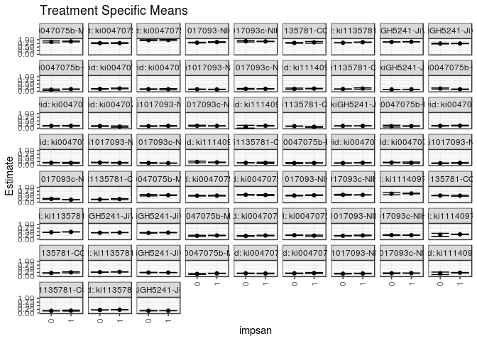

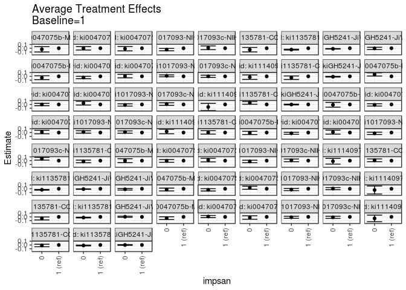

[figure not shown]

## Results Table

### Parameter: TSM

| agecat | studyid | country | intervention_level | baseline_level | estimate | ci_lower | ci_upper |
| --- | --- | --- | --- | --- | --- | --- | --- |
| 0-3 months | ki0047075b-MAL-ED | BANGLADESH | 1 | NA | 0.8815008 | 0.8558139 | 0.9071877 |
| 0-3 months | ki0047075b-MAL-ED | BANGLADESH | 0 | NA | 0.8529386 | 0.7871300 | 0.9187472 |
| 0-3 months | ki0047075b-MAL-ED | INDIA | 1 | NA | 0.7654233 | 0.7348688 | 0.7959778 |
| 0-3 months | ki0047075b-MAL-ED | INDIA | 0 | NA | 0.7636429 | 0.7305121 | 0.7967737 |
| 0-3 months | ki0047075b-MAL-ED | PERU | 1 | NA | 0.9788711 | 0.9294498 | 1.0282924 |
| 0-3 months | ki0047075b-MAL-ED | PERU | 0 | NA | 0.9673722 | 0.9373594 | 0.9973850 |
| 0-3 months | ki1017093-NIH-Birth | BANGLADESH | 1 | NA | 0.8375377 | 0.8138893 | 0.8611861 |
| 0-3 months | ki1017093-NIH-Birth | BANGLADESH | 0 | NA | 0.8017932 | 0.7796859 | 0.8239006 |
| 0-3 months | ki1017093c-NIH-Crypto | BANGLADESH | 1 | NA | 0.8828578 | 0.8675195 | 0.8981960 |
| 0-3 months | ki1017093c-NIH-Crypto | BANGLADESH | 0 | NA | 0.8949821 | 0.8480756 | 0.9418887 |
| 0-3 months | ki1135781-COHORTS | GUATEMALA | 1 | NA | 0.8205633 | 0.7655924 | 0.8755341 |
| 0-3 months | ki1135781-COHORTS | GUATEMALA | 0 | NA | 0.7825878 | 0.7603494 | 0.8048261 |
| 0-3 months | ki1135781-COHORTS | INDIA | 1 | NA | 0.8281532 | 0.8187794 | 0.8375270 |
| 0-3 months | ki1135781-COHORTS | INDIA | 0 | NA | 0.7909995 | 0.7839539 | 0.7980452 |
| 0-3 months | kiGH5241-JiVitA-3 | BANGLADESH | 1 | NA | 0.8621053 | 0.8585635 | 0.8656470 |
| 0-3 months | kiGH5241-JiVitA-3 | BANGLADESH | 0 | NA | 0.8472932 | 0.8418757 | 0.8527107 |
| 0-3 months | kiGH5241-JiVitA-4 | BANGLADESH | 1 | NA | 0.7405934 | 0.7252710 | 0.7559158 |
| 0-3 months | kiGH5241-JiVitA-4 | BANGLADESH | 0 | NA | 0.7364422 | 0.7096914 | 0.7631930 |
| 3-6 months | ki0047075b-MAL-ED | BANGLADESH | 1 | NA | 0.4754021 | 0.4574820 | 0.4933222 |
| 3-6 months | ki0047075b-MAL-ED | BANGLADESH | 0 | NA | 0.4741395 | 0.4250893 | 0.5231897 |
| 3-6 months | ki0047075b-MAL-ED | INDIA | 1 | NA | 0.4456657 | 0.4187108 | 0.4726207 |
| 3-6 months | ki0047075b-MAL-ED | INDIA | 0 | NA | 0.4395787 | 0.4157998 | 0.4633577 |
| 3-6 months | ki0047075b-MAL-ED | PERU | 1 | NA | 0.4874248 | 0.4458891 | 0.5289606 |
| 3-6 months | ki0047075b-MAL-ED | PERU | 0 | NA | 0.5032080 | 0.4800101 | 0.5264059 |
| 3-6 months | ki1017093-NIH-Birth | BANGLADESH | 1 | NA | 0.4726052 | 0.4483183 | 0.4968922 |
| 3-6 months | ki1017093-NIH-Birth | BANGLADESH | 0 | NA | 0.4508688 | 0.4274786 | 0.4742590 |
| 3-6 months | ki1017093c-NIH-Crypto | BANGLADESH | 1 | NA | 0.4955607 | 0.4837693 | 0.5073522 |
| 3-6 months | ki1017093c-NIH-Crypto | BANGLADESH | 0 | NA | 0.5032617 | 0.4698989 | 0.5366245 |
| 3-6 months | ki1114097-CONTENT | PERU | 1 | NA | 0.5910684 | 0.5688965 | 0.6132403 |
| 3-6 months | ki1114097-CONTENT | PERU | 0 | NA | 0.5758420 | 0.5042454 | 0.6474386 |

[output cut: 102 more lines]

### Parameter: E(Y)

| agecat | studyid | country | intervention_level | baseline_level | estimate | ci_lower | ci_upper |
| --- | --- | --- | --- | --- | --- | --- | --- |
| 0-3 months | ki0047075b-MAL-ED | BANGLADESH | NA | NA | 0.8772390 | 0.8535646 | 0.9009134 |
| 0-3 months | ki0047075b-MAL-ED | INDIA | NA | NA | 0.7620085 | 0.7394216 | 0.7845954 |
| 0-3 months | ki0047075b-MAL-ED | PERU | NA | NA | 0.9689288 | 0.9429768 | 0.9948807 |
| 0-3 months | ki1017093-NIH-Birth | BANGLADESH | NA | NA | 0.8163500 | 0.7995330 | 0.8331670 |
| 0-3 months | ki1017093c-NIH-Crypto | BANGLADESH | NA | NA | 0.8845080 | 0.8697896 | 0.8992264 |
| 0-3 months | ki1135781-COHORTS | GUATEMALA | NA | NA | 0.7842946 | 0.7633006 | 0.8052885 |
| 0-3 months | ki1135781-COHORTS | INDIA | NA | NA | 0.8055731 | 0.8001316 | 0.8110146 |
| 0-3 months | kiGH5241-JiVitA-3 | BANGLADESH | NA | NA | 0.8576914 | 0.8546747 | 0.8607082 |
| 0-3 months | kiGH5241-JiVitA-4 | BANGLADESH | NA | NA | 0.7394732 | 0.7257200 | 0.7532264 |
| 3-6 months | ki0047075b-MAL-ED | BANGLADESH | NA | NA | 0.4746501 | 0.4579760 | 0.4913241 |
| 3-6 months | ki0047075b-MAL-ED | INDIA | NA | NA | 0.4449792 | 0.4272939 | 0.4626645 |
| 3-6 months | ki0047075b-MAL-ED | PERU | NA | NA | 0.4981398 | 0.4788320 | 0.5174477 |
| 3-6 months | ki1017093-NIH-Birth | BANGLADESH | NA | NA | 0.4593975 | 0.4422221 | 0.4765729 |
| 3-6 months | ki1017093c-NIH-Crypto | BANGLADESH | NA | NA | 0.4982529 | 0.4871014 | 0.5094044 |
| 3-6 months | ki1114097-CONTENT | PERU | NA | NA | 0.5883606 | 0.5672514 | 0.6094698 |
| 3-6 months | ki1135781-COHORTS | GUATEMALA | NA | NA | 0.4507062 | 0.4376433 | 0.4637691 |
| 3-6 months | ki1135781-COHORTS | INDIA | NA | NA | 0.4758823 | 0.4714157 | 0.4803490 |
| 3-6 months | kiGH5241-JiVitA-3 | BANGLADESH | NA | NA | 0.4413966 | 0.4384254 | 0.4443678 |
| 3-6 months | kiGH5241-JiVitA-4 | BANGLADESH | NA | NA | 0.4391710 | 0.4303780 | 0.4479640 |
| 6-9 months | ki0047075b-MAL-ED | BANGLADESH | NA | NA | 0.2428552 | 0.2283339 | 0.2573765 |
| 6-9 months | ki0047075b-MAL-ED | INDIA | NA | NA | 0.2329150 | 0.2179398 | 0.2478901 |
| 6-9 months | ki0047075b-MAL-ED | PERU | NA | NA | 0.2596511 | 0.2439596 | 0.2753427 |
| 6-9 months | ki1017093-NIH-Birth | BANGLADESH | NA | NA | 0.2362596 | 0.2225288 | 0.2499904 |
| 6-9 months | ki1017093c-NIH-Crypto | BANGLADESH | NA | NA | 0.2668023 | 0.2561807 | 0.2774240 |
| 6-9 months | ki1114097-CONTENT | PERU | NA | NA | 0.3203724 | 0.3008854 | 0.3398595 |
| 6-9 months | ki1135781-COHORTS | GUATEMALA | NA | NA | 0.2132733 | 0.2018429 | 0.2247038 |
| 6-9 months | ki1135781-COHORTS | INDIA | NA | NA | 0.2732584 | 0.2685932 | 0.2779236 |
| 6-9 months | kiGH5241-JiVitA-4 | BANGLADESH | NA | NA | 0.2398525 | 0.2345783 | 0.2451267 |
| 9-12 months | ki0047075b-MAL-ED | BANGLADESH | NA | NA | 0.1730346 | 0.1593686 | 0.1867006 |
| 9-12 months | ki0047075b-MAL-ED | INDIA | NA | NA | 0.1787090 | 0.1645315 | 0.1928865 |
| 9-12 months | ki0047075b-MAL-ED | PERU | NA | NA | 0.1877302 | 0.1721772 | 0.2032832 |
| 9-12 months | ki1017093-NIH-Birth | BANGLADESH | NA | NA | 0.1636213 | 0.1504841 | 0.1767585 |
| 9-12 months | ki1017093c-NIH-Crypto | BANGLADESH | NA | NA | 0.1982735 | 0.1877823 | 0.2087647 |
| 9-12 months | ki1114097-CONTENT | PERU | NA | NA | 0.2242885 | 0.2061680 | 0.2424089 |
| 9-12 months | ki1135781-COHORTS | GUATEMALA | NA | NA | 0.1506988 | 0.1402747 | 0.1611229 |
| 9-12 months | ki1135781-COHORTS | INDIA | NA | NA | 0.2137973 | 0.2089688 | 0.2186259 |
| 9-12 months | kiGH5241-JiVitA-4 | BANGLADESH | NA | NA | 0.1545123 | 0.1502488 | 0.1587759 |
| 12-15 months | ki0047075b-MAL-ED | BANGLADESH | NA | NA | 0.1353586 | 0.1195861 | 0.1511312 |
| 12-15 months | ki0047075b-MAL-ED | INDIA | NA | NA | 0.1737542 | 0.1580843 | 0.1894241 |
| 12-15 months | ki0047075b-MAL-ED | PERU | NA | NA | 0.1412986 | 0.1241913 | 0.1584059 |
| 12-15 months | ki1017093-NIH-Birth | BANGLADESH | NA | NA | 0.1305063 | 0.1184818 | 0.1425307 |
| 12-15 months | ki1017093c-NIH-Crypto | BANGLADESH | NA | NA | 0.1649159 | 0.1542644 | 0.1755674 |
| 12-15 months | ki1114097-CONTENT | PERU | NA | NA | 0.1810659 | 0.1624244 | 0.1997074 |
| 12-15 months | ki1135781-COHORTS | GUATEMALA | NA | NA | 0.1509490 | 0.1404302 | 0.1614679 |
| 12-15 months | kiGH5241-JiVitA-4 | BANGLADESH | NA | NA | 0.1304576 | 0.1263404 | 0.1345747 |
| 15-18 months | ki0047075b-MAL-ED | BANGLADESH | NA | NA | 0.1427882 | 0.1271818 | 0.1583946 |
| 15-18 months | ki0047075b-MAL-ED | INDIA | NA | NA | 0.1620281 | 0.1470182 | 0.1770381 |
| 15-18 months | ki0047075b-MAL-ED | PERU | NA | NA | 0.1449378 | 0.1257292 | 0.1641464 |
| 15-18 months | ki1017093-NIH-Birth | BANGLADESH | NA | NA | 0.1529843 | 0.1384423 | 0.1675263 |
| 15-18 months | ki1017093c-NIH-Crypto | BANGLADESH | NA | NA | 0.1608018 | 0.1501273 | 0.1714764 |
| 15-18 months | ki1114097-CONTENT | PERU | NA | NA | 0.1713509 | 0.1529966 | 0.1897053 |
| 15-18 months | ki1135781-COHORTS | GUATEMALA | NA | NA | 0.1376203 | 0.1254069 | 0.1498336 |
| 15-18 months | kiGH5241-JiVitA-4 | BANGLADESH | NA | NA | 0.1595310 | 0.1548323 | 0.1642296 |
| 18-21 months | ki0047075b-MAL-ED | BANGLADESH | NA | NA | 0.1427146 | 0.1257942 | 0.1596351 |
| 18-21 months | ki0047075b-MAL-ED | INDIA | NA | NA | 0.1741118 | 0.1592007 | 0.1890230 |
| 18-21 months | ki0047075b-MAL-ED | PERU | NA | NA | 0.1632287 | 0.1439532 | 0.1825042 |
| 18-21 months | ki1017093-NIH-Birth | BANGLADESH | NA | NA | 0.1724392 | 0.1563209 | 0.1885575 |
| 18-21 months | ki1017093c-NIH-Crypto | BANGLADESH | NA | NA | 0.1417284 | 0.1308558 | 0.1526011 |
| 18-21 months | ki1114097-CONTENT | PERU | NA | NA | 0.1921232 | 0.1732877 | 0.2109588 |
| 18-21 months | ki1135781-COHORTS | GUATEMALA | NA | NA | 0.1624730 | 0.1508586 | 0.1740875 |
| 21-24 months | ki0047075b-MAL-ED | BANGLADESH | NA | NA | 0.1521155 | 0.1369898 | 0.1672413 |
| 21-24 months | ki0047075b-MAL-ED | INDIA | NA | NA | 0.1561228 | 0.1429524 | 0.1692932 |
| 21-24 months | ki0047075b-MAL-ED | PERU | NA | NA | 0.1789625 | 0.1588192 | 0.1991058 |
| 21-24 months | ki1017093-NIH-Birth | BANGLADESH | NA | NA | 0.1419730 | 0.1267767 | 0.1571693 |
| 21-24 months | ki1017093c-NIH-Crypto | BANGLADESH | NA | NA | 0.1750178 | 0.1622174 | 0.1878182 |
| 21-24 months | ki1135781-COHORTS | GUATEMALA | NA | NA | 0.1872542 | 0.1759502 | 0.1985583 |

### Parameter: ATE

| agecat | studyid | country | intervention_level | baseline_level | estimate | ci_lower | ci_upper |
| --- | --- | --- | --- | --- | --- | --- | --- |
| 0-3 months | ki0047075b-MAL-ED | BANGLADESH | 1 | 1 | 0.0000000 | 0.0000000 | 0.0000000 |
| 0-3 months | ki0047075b-MAL-ED | BANGLADESH | 0 | 1 | -0.0285622 | -0.0992720 | 0.0421475 |
| 0-3 months | ki0047075b-MAL-ED | INDIA | 1 | 1 | 0.0000000 | 0.0000000 | 0.0000000 |
| 0-3 months | ki0047075b-MAL-ED | INDIA | 0 | 1 | -0.0017804 | -0.0469502 | 0.0433894 |
| 0-3 months | ki0047075b-MAL-ED | PERU | 1 | 1 | 0.0000000 | 0.0000000 | 0.0000000 |
| 0-3 months | ki0047075b-MAL-ED | PERU | 0 | 1 | -0.0114989 | -0.0691629 | 0.0461651 |
| 0-3 months | ki1017093-NIH-Birth | BANGLADESH | 1 | 1 | 0.0000000 | 0.0000000 | 0.0000000 |
| 0-3 months | ki1017093-NIH-Birth | BANGLADESH | 0 | 1 | -0.0357445 | -0.0674547 | -0.0040343 |
| 0-3 months | ki1017093c-NIH-Crypto | BANGLADESH | 1 | 1 | 0.0000000 | 0.0000000 | 0.0000000 |
| 0-3 months | ki1017093c-NIH-Crypto | BANGLADESH | 0 | 1 | 0.0121244 | -0.0369023 | 0.0611510 |
| 0-3 months | ki1135781-COHORTS | GUATEMALA | 1 | 1 | 0.0000000 | 0.0000000 | 0.0000000 |
| 0-3 months | ki1135781-COHORTS | GUATEMALA | 0 | 1 | -0.0379755 | -0.0971578 | 0.0212068 |
| 0-3 months | ki1135781-COHORTS | INDIA | 1 | 1 | 0.0000000 | 0.0000000 | 0.0000000 |
| 0-3 months | ki1135781-COHORTS | INDIA | 0 | 1 | -0.0371537 | -0.0488266 | -0.0254807 |
| 0-3 months | kiGH5241-JiVitA-3 | BANGLADESH | 1 | 1 | 0.0000000 | 0.0000000 | 0.0000000 |
| 0-3 months | kiGH5241-JiVitA-3 | BANGLADESH | 0 | 1 | -0.0148121 | -0.0208300 | -0.0087941 |
| 0-3 months | kiGH5241-JiVitA-4 | BANGLADESH | 1 | 1 | 0.0000000 | 0.0000000 | 0.0000000 |
| 0-3 months | kiGH5241-JiVitA-4 | BANGLADESH | 0 | 1 | -0.0041511 | -0.0343343 | 0.0260320 |
| 3-6 months | ki0047075b-MAL-ED | BANGLADESH | 1 | 1 | 0.0000000 | 0.0000000 | 0.0000000 |
| 3-6 months | ki0047075b-MAL-ED | BANGLADESH | 0 | 1 | -0.0012626 | -0.0535346 | 0.0510095 |
| 3-6 months | ki0047075b-MAL-ED | INDIA | 1 | 1 | 0.0000000 | 0.0000000 | 0.0000000 |
| 3-6 months | ki0047075b-MAL-ED | INDIA | 0 | 1 | -0.0060870 | -0.0426529 | 0.0304789 |
| 3-6 months | ki0047075b-MAL-ED | PERU | 1 | 1 | 0.0000000 | 0.0000000 | 0.0000000 |
| 3-6 months | ki0047075b-MAL-ED | PERU | 0 | 1 | 0.0157832 | -0.0318542 | 0.0634205 |
| 3-6 months | ki1017093-NIH-Birth | BANGLADESH | 1 | 1 | 0.0000000 | 0.0000000 | 0.0000000 |
| 3-6 months | ki1017093-NIH-Birth | BANGLADESH | 0 | 1 | -0.0217365 | -0.0555868 | 0.0121139 |
| 3-6 months | ki1017093c-NIH-Crypto | BANGLADESH | 1 | 1 | 0.0000000 | 0.0000000 | 0.0000000 |
| 3-6 months | ki1017093c-NIH-Crypto | BANGLADESH | 0 | 1 | 0.0077010 | -0.0277517 | 0.0431536 |
| 3-6 months | ki1114097-CONTENT | PERU | 1 | 1 | 0.0000000 | 0.0000000 | 0.0000000 |
| 3-6 months | ki1114097-CONTENT | PERU | 0 | 1 | -0.0152264 | -0.0901714 | 0.0597187 |

[output cut: 102 more lines]

### Parameter: PAR

| agecat | studyid | country | intervention_level | baseline_level | estimate | ci_lower | ci_upper |
| --- | --- | --- | --- | --- | --- | --- | --- |
| 0-3 months | ki0047075b-MAL-ED | BANGLADESH | 1 | NA | -0.0042618 | -0.0144939 | 0.0059702 |
| 0-3 months | ki0047075b-MAL-ED | INDIA | 1 | NA | -0.0034148 | -0.0278361 | 0.0210066 |
| 0-3 months | ki0047075b-MAL-ED | PERU | 1 | NA | -0.0099423 | -0.0539823 | 0.0340977 |
| 0-3 months | ki1017093-NIH-Birth | BANGLADESH | 1 | NA | -0.0211877 | -0.0409536 | -0.0014219 |
| 0-3 months | ki1017093c-NIH-Crypto | BANGLADESH | 1 | NA | 0.0016502 | -0.0041732 | 0.0074737 |
| 0-3 months | ki1135781-COHORTS | GUATEMALA | 1 | NA | -0.0362687 | -0.0891699 | 0.0166326 |
| 0-3 months | ki1135781-COHORTS | INDIA | 1 | NA | -0.0225801 | -0.0302443 | -0.0149159 |
| 0-3 months | kiGH5241-JiVitA-3 | BANGLADESH | 1 | NA | -0.0044138 | -0.0061958 | -0.0026318 |
| 0-3 months | kiGH5241-JiVitA-4 | BANGLADESH | 1 | NA | -0.0011201 | -0.0083302 | 0.0060899 |
| 3-6 months | ki0047075b-MAL-ED | BANGLADESH | 1 | NA | -0.0007520 | -0.0087596 | 0.0072556 |
| 3-6 months | ki0047075b-MAL-ED | INDIA | 1 | NA | -0.0006865 | -0.0203081 | 0.0189350 |
| 3-6 months | ki0047075b-MAL-ED | PERU | 1 | NA | 0.0107150 | -0.0275778 | 0.0490078 |
| 3-6 months | ki1017093-NIH-Birth | BANGLADESH | 1 | NA | -0.0132078 | -0.0343393 | 0.0079238 |
| 3-6 months | ki1017093c-NIH-Crypto | BANGLADESH | 1 | NA | 0.0026921 | -0.0018035 | 0.0071878 |
| 3-6 months | ki1114097-CONTENT | PERU | 1 | NA | -0.0027078 | -0.0070652 | 0.0016496 |
| 3-6 months | ki1135781-COHORTS | GUATEMALA | 1 | NA | 0.0098703 | -0.0236582 | 0.0433988 |
| 3-6 months | ki1135781-COHORTS | INDIA | 1 | NA | -0.0156674 | -0.0216774 | -0.0096574 |
| 3-6 months | kiGH5241-JiVitA-3 | BANGLADESH | 1 | NA | -0.0019905 | -0.0037445 | -0.0002365 |
| 3-6 months | kiGH5241-JiVitA-4 | BANGLADESH | 1 | NA | -0.0030057 | -0.0076738 | 0.0016624 |
| 6-9 months | ki0047075b-MAL-ED | BANGLADESH | 1 | NA | -0.0034829 | -0.0092379 | 0.0022722 |
| 6-9 months | ki0047075b-MAL-ED | INDIA | 1 | NA | -0.0125338 | -0.0290595 | 0.0039919 |
| 6-9 months | ki0047075b-MAL-ED | PERU | 1 | NA | 0.0235500 | -0.0099152 | 0.0570152 |
| 6-9 months | ki1017093-NIH-Birth | BANGLADESH | 1 | NA | -0.0131721 | -0.0311893 | 0.0048450 |
| 6-9 months | ki1017093c-NIH-Crypto | BANGLADESH | 1 | NA | 0.0002852 | -0.0032179 | 0.0037883 |
| 6-9 months | ki1114097-CONTENT | PERU | 1 | NA | -0.0031246 | -0.0087796 | 0.0025304 |
| 6-9 months | ki1135781-COHORTS | GUATEMALA | 1 | NA | -0.0382445 | -0.0743249 | -0.0021640 |
| 6-9 months | ki1135781-COHORTS | INDIA | 1 | NA | -0.0107281 | -0.0168939 | -0.0045623 |
| 6-9 months | kiGH5241-JiVitA-4 | BANGLADESH | 1 | NA | 0.0004383 | -0.0023020 | 0.0031786 |
| 9-12 months | ki0047075b-MAL-ED | BANGLADESH | 1 | NA | -0.0054896 | -0.0108979 | -0.0000814 |
| 9-12 months | ki0047075b-MAL-ED | INDIA | 1 | NA | 0.0041903 | -0.0117436 | 0.0201242 |
| 9-12 months | ki0047075b-MAL-ED | PERU | 1 | NA | -0.0134427 | -0.0522926 | 0.0254072 |
| 9-12 months | ki1017093-NIH-Birth | BANGLADESH | 1 | NA | -0.0082661 | -0.0245727 | 0.0080406 |
| 9-12 months | ki1017093c-NIH-Crypto | BANGLADESH | 1 | NA | -0.0001054 | -0.0037463 | 0.0035355 |
| 9-12 months | ki1114097-CONTENT | PERU | 1 | NA | -0.0028976 | -0.0083854 | 0.0025903 |
| 9-12 months | ki1135781-COHORTS | GUATEMALA | 1 | NA | -0.0124151 | -0.0426752 | 0.0178450 |
| 9-12 months | ki1135781-COHORTS | INDIA | 1 | NA | -0.0066059 | -0.0129501 | -0.0002617 |
| 9-12 months | kiGH5241-JiVitA-4 | BANGLADESH | 1 | NA | 0.0004768 | -0.0018271 | 0.0027806 |
| 12-15 months | ki0047075b-MAL-ED | BANGLADESH | 1 | NA | -0.0069142 | -0.0147907 | 0.0009622 |
| 12-15 months | ki0047075b-MAL-ED | INDIA | 1 | NA | -0.0182631 | -0.0357149 | -0.0008114 |
| 12-15 months | ki0047075b-MAL-ED | PERU | 1 | NA | 0.0034269 | -0.0346116 | 0.0414654 |
| 12-15 months | ki1017093-NIH-Birth | BANGLADESH | 1 | NA | 0.0076575 | -0.0076382 | 0.0229532 |
| 12-15 months | ki1017093c-NIH-Crypto | BANGLADESH | 1 | NA | 0.0000132 | -0.0038381 | 0.0038645 |
| 12-15 months | ki1114097-CONTENT | PERU | 1 | NA | -0.0007264 | -0.0048621 | 0.0034092 |
| 12-15 months | ki1135781-COHORTS | GUATEMALA | 1 | NA | -0.0352885 | -0.0791999 | 0.0086229 |
| 12-15 months | kiGH5241-JiVitA-4 | BANGLADESH | 1 | NA | -0.0023111 | -0.0043716 | -0.0002505 |
| 15-18 months | ki0047075b-MAL-ED | BANGLADESH | 1 | NA | 0.0065028 | -0.0007049 | 0.0137106 |
| 15-18 months | ki0047075b-MAL-ED | INDIA | 1 | NA | -0.0041214 | -0.0207388 | 0.0124961 |
| 15-18 months | ki0047075b-MAL-ED | PERU | 1 | NA | 0.0326386 | -0.0083004 | 0.0735776 |
| 15-18 months | ki1017093-NIH-Birth | BANGLADESH | 1 | NA | -0.0068507 | -0.0249554 | 0.0112540 |
| 15-18 months | ki1017093c-NIH-Crypto | BANGLADESH | 1 | NA | 0.0013593 | -0.0034083 | 0.0061270 |
| 15-18 months | ki1114097-CONTENT | PERU | 1 | NA | 0.0035540 | -0.0019481 | 0.0090560 |
| 15-18 months | ki1135781-COHORTS | GUATEMALA | 1 | NA | 0.0395503 | 0.0066112 | 0.0724895 |
| 15-18 months | kiGH5241-JiVitA-4 | BANGLADESH | 1 | NA | -0.0004449 | -0.0028758 | 0.0019860 |
| 18-21 months | ki0047075b-MAL-ED | BANGLADESH | 1 | NA | -0.0074331 | -0.0169480 | 0.0020818 |
| 18-21 months | ki0047075b-MAL-ED | INDIA | 1 | NA | -0.0038761 | -0.0204750 | 0.0127227 |
| 18-21 months | ki0047075b-MAL-ED | PERU | 1 | NA | 0.0095876 | -0.0279745 | 0.0471497 |
| 18-21 months | ki1017093-NIH-Birth | BANGLADESH | 1 | NA | 0.0097584 | -0.0096301 | 0.0291469 |
| 18-21 months | ki1017093c-NIH-Crypto | BANGLADESH | 1 | NA | 0.0007286 | -0.0034692 | 0.0049263 |
| 18-21 months | ki1114097-CONTENT | PERU | 1 | NA | 0.0014686 | -0.0026517 | 0.0055889 |
| 18-21 months | ki1135781-COHORTS | GUATEMALA | 1 | NA | 0.0039997 | -0.0380944 | 0.0460939 |
| 21-24 months | ki0047075b-MAL-ED | BANGLADESH | 1 | NA | -0.0011631 | -0.0065134 | 0.0041871 |
| 21-24 months | ki0047075b-MAL-ED | INDIA | 1 | NA | -0.0099864 | -0.0245308 | 0.0045580 |
| 21-24 months | ki0047075b-MAL-ED | PERU | 1 | NA | 0.0123009 | -0.0292955 | 0.0538972 |
| 21-24 months | ki1017093-NIH-Birth | BANGLADESH | 1 | NA | -0.0131457 | -0.0319990 | 0.0057077 |
| 21-24 months | ki1017093c-NIH-Crypto | BANGLADESH | 1 | NA | 0.0071416 | 0.0018387 | 0.0124445 |
| 21-24 months | ki1135781-COHORTS | GUATEMALA | 1 | NA | -0.0190935 | -0.0518498 | 0.0136628 |